# Decision Tree Regression:

## Purpose of this notebook

In this notebook, data is generated fictitiously to explain the functionality of decision trees. The focus here is on the **visualization of the regression tree with regards to the data points and the tree structure**. The fact that a clear overfitting takes place AND not train-test-splitting is performed is therefore irrelevant.

Feel free to alter some hyperparameter and test new ones to see how it affects the tree structure. Here you'll find the [scikit learn documentation](https://scikit-learn.org/stable/modules/generated/sklearn.tree.DecisionTreeRegressor.html).

## Import the required libraries

```python
# Import packages
import numpy as np
import pandas as pd
import matplotlib.pyplot as plt
```

## The Data

We will create a fictitous dataset about video games including the type of the game, the production cost and the profit for 14 games.

```python
# Data description: Name, Production Cost, Profit.
dataset = np.array(
[['Asset Flip', 100, 1000],
['Text Based', 500, 3000],
['Visual Novel', 1500, 5000],
['2D Pixel Art', 3500, 8000],
['2D Vector Art', 5000, 6500],
['Strategy', 6000, 7000],
['First Person Shooter', 8000, 15000],
['Simulator', 9500, 20000],
['Racing', 12000, 21000],
['RPG', 14000, 25000],
['Sandbox', 15500, 27000],
['Open-World', 16500, 30000],
['MMOFPS', 25000, 52000],
['MMORPG', 30000, 80000]
])

# print the dataset
print(dataset)
```

```
[['Asset Flip' '100' '1000']
 ['Text Based' '500' '3000']
 ['Visual Novel' '1500' '5000']
 ['2D Pixel Art' '3500' '8000']
 ['2D Vector Art' '5000' '6500']
 ['Strategy' '6000' '7000']
 ['First Person Shooter' '8000' '15000']
 ['Simulator' '9500' '20000']
 ['Racing' '12000' '21000']
 ['RPG' '14000' '25000']
 ['Sandbox' '15500' '27000']
 ['Open-World' '16500' '30000']
 ['MMOFPS' '25000' '52000']
 ['MMORPG' '30000' '80000']]
```

## Define feature

We will select the second column (production cost) as the feature we will feed into our Decision Tree.

```python
# select all rows from production cost column
X = dataset[:, 1:2].astype(int)

# print X
print(X)
```

```
[[  100]
 [  500]
 [ 1500]
 [ 3500]
 [ 5000]
 [ 6000]
 [ 8000]
 [ 9500]
 [12000]
 [14000]
 [15500]
 [16500]
 [25000]
 [30000]]
```

## Define the target

We will define the elements in the third column (profit) as our target variable.

```python
# select all rows from profit column to represent the labels
y = dataset[:, 2].astype(int)

# print y
print(y)
```

```
[ 1000  3000  5000  8000  6500  7000 15000 20000 21000 25000 27000 30000
 52000 80000]
```

## Modelling

We will train our `DecisionTreeRegressor` on the complete dataset. In a second step we will use the fitted model to predict the profit for a new instance.

```python
# import the regressor
from sklearn.tree import DecisionTreeRegressor

# create a regressor object
dec_tree = DecisionTreeRegressor()

# fit the regressor with X and Y data
dec_tree.fit(X, y)
```

```
DecisionTreeRegressor()
```

You can try to change some parameters of the decision tree stated here, like `max_depth`, `max_features` etc. to see how it affects the results below.

```python
# predicting a new value
# test the output by changing values, like 3750
y_pred = dec_tree.predict(np.array(3750).reshape(1, -1))

# print the predicted price
print("Predicted Profit: % d\n"% y_pred)
```

```
Predicted Profit:  8000
```

## Visualising the result

We can visualise our decision tree and the results in various ways. The first plot shows for which production costs our model predicts which prices.

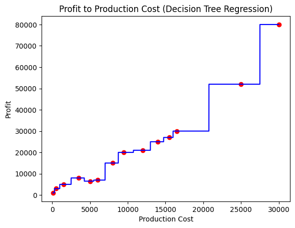

```python
# use np.arange for creating a range of values from min value of X to max value of X
# with a difference of 0.01 between two consecutive values
X_grid = np.arange(min(X), max(X), 0.01)

# use .reshape for reshaping the data into a len(X_grid)*1 array, i.e. to make
# a column out of the X_grid values
X_grid = X_grid.reshape((len(X_grid), 1))

# scatter plot for original data
plt.scatter(X, y, color = 'red')

# plot predicted data
plt.plot(X_grid, dec_tree.predict(X_grid), color = 'blue')

# specify title and labels
plt.title('Profit to Production Cost (Decision Tree Regression)')
plt.xlabel('Production Cost')
plt.ylabel('Profit')

# show the plot
plt.show()
```

In this plot, we have *Profit* on the vertical axis and *Production Cost* on the horizontal axis. The plot jumps up (and occasionally down) in steps, and remains horizontal in between steps. In other words, the plot is a collection of horizontal line segments connected by vertical line segments. Each horizontal segment passes through one data point.

In the second plot you can see a visual representation of our decision tree from the stump to the leaves. We will use [sklearns `plot_tree()`](https://scikit-learn.org/stable/modules/generated/sklearn.tree.plot_tree.html) function for this.

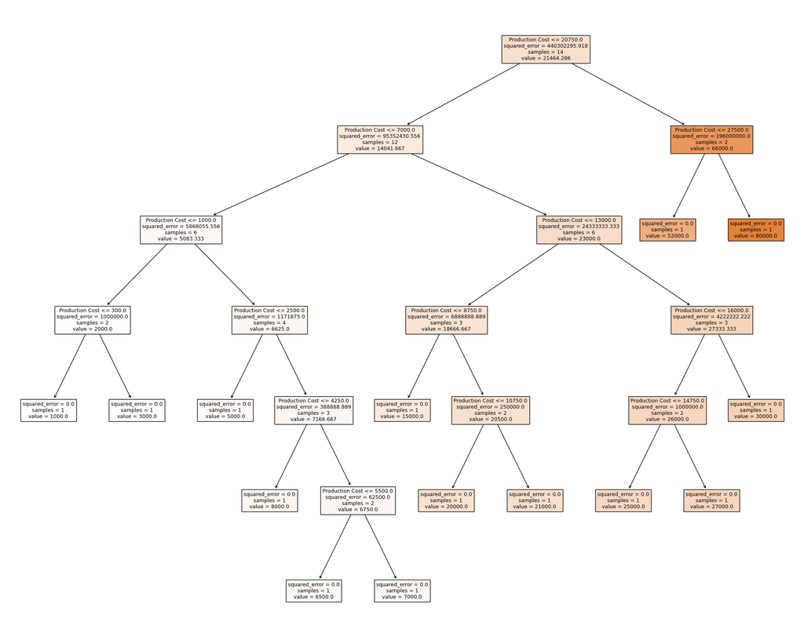

```python
# import necessary library
from sklearn.tree import plot_tree

fig = plt.figure(figsize=(25,20))
dectree_plot = plot_tree(dec_tree,feature_names=['Production Cost'], filled=True)

# You can export the graphic with the following command
# plt.savefig('decision_tree')
```